# 因果推断简介之八：吸烟是否导致肺癌？Fisher versus Cornfield

丁鹏

2013-09-17T10:30:03+00:00

`$$ \def\ind{{\perp\!\!\!\perp}} \def\nind{{\not\!\perp\!\!\!\perp}} $$`

这一节介绍一个有趣的历史性例子：吸烟是否导致肺癌？主要涉及的人物是 R A Fisher 和 J Cornfield。前者估计上这个网站的人都听过，后者就显得比较陌生了。事实上，Cornfield 在统计、生物统计和流行病学都有着非常重要的贡献。来自 Wikipedia 的一句介绍：“He was the R. A. Fisher Lecturer in 1973 and President of the American Statistical Association in 1974.” 虽然 Cornfield 和 Fisher 学术观点不同（本节介绍），但是 Cornfield 还是在 1973 年给了 Fisher Lecture。

下面我们先介绍 Fisher 和 Cornfield 关于观察性研究中因果推断的两种观点，再给出技术性的细节。

# 一、Cornfield 条件或者 Cornfield 不等式

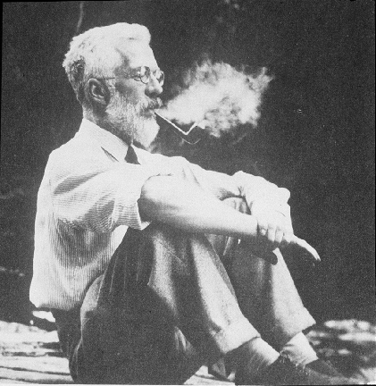

fisher

（图注：R A Fisher）

我先陈述 Fisher 的观点。由于 Yule-Simpson Paradox 的存在，即使我们观测到吸烟和肺癌之间的正相关关系，也不能断定它们之间有因果性。可能存在一个未观测的基因，它既使得某些人更可能吸烟，又使得这些人更可能患肺癌。因此，即使吸烟和肺癌没有因果关系，这个未观测的基因也可能导致吸烟和肺癌是正相关的。关于 Yule-Simpson Paradox，这一系列的第一篇有介绍。Fisher 的观点可以用一个有向无环图 （DAG） 来表示：

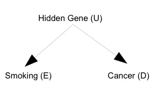

图中，吸烟到肺癌没有直接的边，因此吸烟对肺癌的因果作用是 `\(0\)`。但是由于它们之间存在一个共同原因 “hidden gene”，它们是相关的。我们用 `\(E\)` 表示是否吸烟 (`\(1=\)` 是，`\(0=\)` 否)；`\(D\)` 表示是否患肺癌 (`\(1=\)` 是，`\(0=\)` 否)；`\(U\)` 表示是否有某种基因 (`\(1=\)` 是，`\(0=\)` 否)。这个符号系统在流行病学比较常用，因为 `\(E\)` 表示暴露与否 （exposure），`\(D\)` 表示疾病 （disease），`\(U\)` 表示未观测的混杂因素 （unobservable confounder）。 在 Fisher 的时代，研究者通过收集的大量数据，得到吸烟对于肺癌的相对风险（relative risk；或称风险比，risk ratio；都简写成 `\(RR\)`）是

`$$ RR_{ED}= \frac{ P(D=1\mid E=1) } { P(D=1\mid E=0) } = 9. $$`

流行病学家关心这个 `\(RR_{ED}\)` 是否表明了吸烟和肺癌的因果关系。Fisher 表示否定。从一个悲观的角度来讲，我们确实不能从相关关系得到因果性；Fisher 如果表示怀疑，假定有一个未观测的基因，也是无可反驳的。Fisher 的这个说法有时也被称为“共同原因”假说。Cornfield 则采取了一个不太悲观的角度。他问：如果 Fisher 的“共同原因”假说是对的，那么 `\(E\)` 和 `\(U\)` 之间的相关关系需要多强，才能导致 `\(RR_{ED} = 9\)`，即“吸烟患肺癌”是“不吸烟患肺癌”的风险的 `\(9\)` 倍呢？如果 `\(E\)` 和 `\(U\)` 之间的相关关系强到不具有生物学意义（`\(E\)` 与 `\(U\)` 的相对风险值大得在现实中不太可能），那么 Fisher 的“共同原因”假说就不成立，更大的可能性是吸烟 `\(E\)` 对肺癌 `\(D\)` 有因果作用。

那么 Cornfield 是如何有力反驳Fisher的观点的呢？

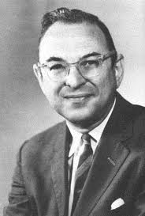

cornfield

（图注：J Cornfield）

Cornfield 通过简单的数学证明，得到了如下的不等式，文献中也称为 Cornfield 不等式：

`$$ RR_{EU} \geq RR_{ED}. $$`

也就是说，如果 Fisher 的“共同原因”假说成立，那么 `\(E\)` 和 `\(U\)` 之间的 `\(RR\)` 必将大于 `\(E\)` 和 `\(D\)` 之间的 `\(RR\)`。在吸烟和肺癌的例子中，`\(RR_{EU} \geq 9\)`。`\(RR_{EU} \geq 9\)`，即 `\(P(U=1|E=1)/P(U=1|E=0) \geq 9\)`，直观解释就是“吸烟时有某个基因 `\(U\)` 存在”的概率是“不吸烟时有某个基因 `\(U\)` 存在”的概率的 `\(9\)` 倍多。根据 Cornfield 进一步的逻辑，由于吸烟更多的是一个社会性的行为，很难想象吸烟的行为能够对于某个基因的存在与否有着 `\(9\)` 倍的预测能力。我前段时间问身边一个生物的 PhD，你觉得 `\(RR_{EU} \geq 9\)` 可能吗？他的回答是不太可能，理由也是说，吸烟更多的决定于社会经济地位、家庭背景等变量，和基因也许有关系，但是不会强到 `\(RR_{EU} \geq 9\)` 的程度。Cornfield et al. (1959) 的原话是：

> … if cigarette smokers have 9 times the risk of nonsmokers for developing lung cancer, and this is not because cigarette smoke is a causal agent, but only because cigarette smokers produce hormone X, then the proportion of hormone-X producers among cigarette smokers must be at least 9 times greater than nonsmokers. If the relative prevalence of hormone-X-producers is considerably less than ninefold, then hormone-X cannot account for the magnitude of the apparent effect.

如果我们相信 Cornfield 的逻辑，`\(RR_{EU} \geq 9\)` 在生物学意义上不太可能，那么 Fisher 的“共同原因”假说就不成立，吸烟对肺癌的确存在因果作用；反映到上面的 `\(DAG\)` 上，吸烟 `\(E\)` 到肺癌 `\(D\)` 有一条直接的边。

Cornfield 的这项简单研究，开始了流行病学和统计学中敏感性分析的研究；比如 Rubin 和 Rosenbaum 很多工作都是在 Cornfield 的启发下做出来的。简单地说，敏感性分析，就是在朝着 Yule-Simpson Paradox 的反方向进行的：复杂虽然总是存在，但是我们相信这个世界并不是疯狂的复杂。

# 二、技术细节

这一部分我们给出 Cornfield 不等式的证明。虽然证明不难，但是想想 Cornfield 于 1959 年用这样一个简单的不等式来反驳 Fisher，就觉得它的历史意义还是不小的。当然不关心技术细节的读者，可以直接忽略本节。关心技术细节的读者，下面的证明虽然冗长，但是只用到非常初等的数学（也许它可以作为一道初等概率论的习题）。

为了简化证明，我们引进一些记号：

`$$ \begin{eqnarray} f_1 = P(U=1\mid E=1), &&f_0 = P(U=1\mid E=0),\\ RR_{EU} = \frac{ P(U=1\mid E=1) }{ P(U=1\mid E=0)} = \frac{f_1} {f_0}, && RR_{UD} = \frac{ P(D=1\mid U=1) }{ P(D=1\mid U=0) }. \end{eqnarray} $$`

不妨假设 `\(RR_{ED}\geq 1\)` 并且 `\(RR_{EU} \geq 1\)`；若不成立，我们总可以重新对这些二值变量的 `\(0\)` 和 `\(1\)` 类进行重新定义。首先，我们在条件独立性 `\(E\ind D|U\)` 下得到 `\(RR_{ED}\)` 的等价表示：

`$$ \begin{eqnarray} RR_{ED} &=& \frac{ P(D=1\mid E=1) } { P(D=1\mid E=0) }\\ &=& \frac{ \sum_{u=0,1}P(D=1, U=u\mid E=1) } {\sum_{u=0,1} P(D=1, U=u\mid E=0) }\\ &=& \frac{ \sum_{u=0,1}P(D=1\mid U=u) P(U=u\mid E=1) } {\sum_{u=0,1} P(D=1\mid U=u) P(U=u\mid E=0) }\\ &=& \frac{ P(D=1\mid U=1)P(U=1\mid E=1) + P(D=1\mid U=0)P(U=0\mid E=1) } { P(D=1\mid U=1)P(U=1\mid E=0) + P(D=1\mid U=0)P(U=0\mid E=0) }\\ &=& \frac{ RR_{UD} f_1 + (1-f_1)}{ RR_{UD} f_0 + (1-f_0)}. \end{eqnarray} $$`

条件 `\(RR_{EU}\geq 1\)` 等价于 `\(f_1\geq f_0\)`，因此，上面 `\(RR_{ED}\)` 是关于 `\(RR_{UD}\)` 的单调递增函数。进一步，

`$$ RR_{ED} \leq \lim_{RR_{UD}\rightarrow +\infty} \frac{ RR_{UD} f_1 + (1-f_1)} { RR_{UD} f_0 + (1-f_0) } = \frac{f_1}{f_0} = RR_{EU}. $$`

由此，Cornfield 不等式得证。

# 三、文献注记

Cornfield 最早的论文发表于 1959 年；由于它的重要性，这篇文章又在 2009 年重印了一次（50 周年纪念）。于是参考文献有两篇，它们是一样的；不过后者多了很多名人的讨论。

- Cornfield J et al. Smoking and lung cancer: recent evidence and a discussion of some questions. JNCI 1959;22:173-203.
- Cornfield J et al. Smoking and lung cancer: recent evidence and a discussion of some questions. Int J Epidemiol 2009;38:1175-91.（本文邀请了 David R Cox 和 Joel B Greenhouse 等人讨论。）

最近 Ding and VanderWeele 重新回访了这个经典问题，给出了更加广泛的结果。

- Ding, Peng and Vanderweele, Tyler J. (2014). Generalized Cornfield conditions for the risk difference, Biometrika, 101:4, 971-977. https://doi.org/10.1093/biomet/asu030